```python
from IPython.display import HTML
HTML('''<script>
code_show=true;
function code_toggle() {
  if (code_show){
    $(\'div.input\').hide();
  } else {
    $(\'div.input\').show();
  }
  code_show = !code_show
}
$( document ).ready(code_toggle);
</script>
  <form action="javascript:code_toggle()">
    <input type="submit" value="点击此处隐藏/显示代码.">
 </form>''')
```

Superstore运营情况分析报告  
**夏仔阳**

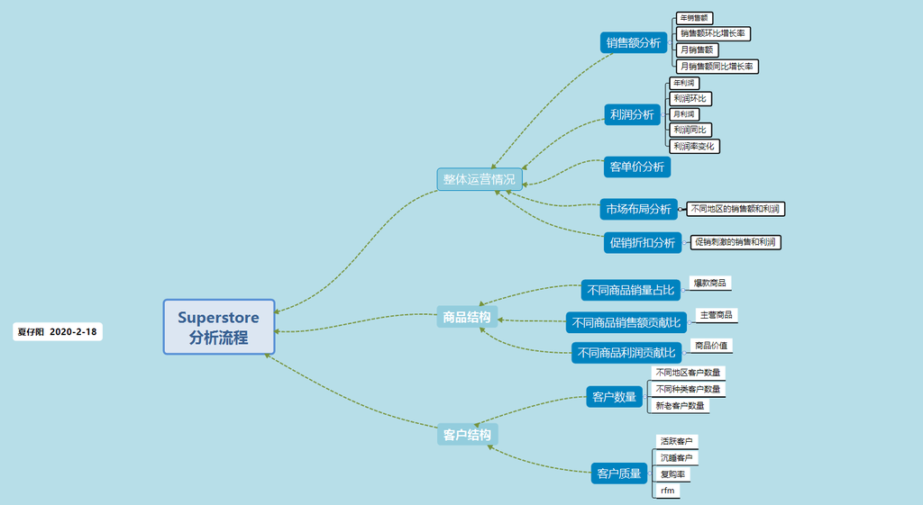

# 数据介绍和处理

数据来源：[superstore_data](https://www.kaggle.com/jr2ngb/superstore-data),共51290条数据，24个字段，字段包括  
Row ID -行编号 Order ID -订单ID Order Date -订单日期 Ship Date -发货日期 Ship Mode -发货模式 Customer ID -客户ID Customer Name -客户姓名 Segment -客户类别 City -客户所在城市 State -客户城市所在州 Country -客户所在国家 Postal Code -邮编 Market -market所属区域 Region -market所属洲 Product ID -产品ID Category -产品类别 Sub-Category -产品子类别 Product Name -产品名称 Sales -销售额 Quantity -销售量 Discount -折扣 Profit -利润 Shipping Cost -发货成本 Order Priority -订单优先级

```python
%config InlineBackend.figure_format='retina'
import pandas as pd
import numpy as np
import matplotlib.pyplot as plt
import seaborn as sns
import warnings
import gc
warnings.filterwarnings('ignore')
```

```python
ogdata=pd.read_csv('superstore_dataset2011-2015.csv',encoding ='ISO-8859-1')
ogdata.head()
```

|  | Row ID | Order ID | Order Date | Ship Date | Ship Mode | Customer ID | Customer Name | Segment | City | State | ... | Product ID | Category | Sub-Category | Product Name | Sales | Quantity | Discount | Profit | Shipping Cost | Order Priority |
| --- | --- | --- | --- | --- | --- | --- | --- | --- | --- | --- | --- | --- | --- | --- | --- | --- | --- | --- | --- | --- | --- |
| 0 | 42433 | AG-2011-2040 | 1/1/2011 | 6/1/2011 | Standard Class | TB-11280 | Toby Braunhardt | Consumer | Constantine | Constantine | ... | OFF-TEN-10000025 | Office Supplies | Storage | Tenex Lockers, Blue | 408.300 | 2 | 0.0 | 106.140 | 35.46 | Medium |
| 1 | 22253 | IN-2011-47883 | 1/1/2011 | 8/1/2011 | Standard Class | JH-15985 | Joseph Holt | Consumer | Wagga Wagga | New South Wales | ... | OFF-SU-10000618 | Office Supplies | Supplies | Acme Trimmer, High Speed | 120.366 | 3 | 0.1 | 36.036 | 9.72 | Medium |
| 2 | 48883 | HU-2011-1220 | 1/1/2011 | 5/1/2011 | Second Class | AT-735 | Annie Thurman | Consumer | Budapest | Budapest | ... | OFF-TEN-10001585 | Office Supplies | Storage | Tenex Box, Single Width | 66.120 | 4 | 0.0 | 29.640 | 8.17 | High |
| 3 | 11731 | IT-2011-3647632 | 1/1/2011 | 5/1/2011 | Second Class | EM-14140 | Eugene Moren | Home Office | Stockholm | Stockholm | ... | OFF-PA-10001492 | Office Supplies | Paper | Enermax Note Cards, Premium | 44.865 | 3 | 0.5 | -26.055 | 4.82 | High |
| 4 | 22255 | IN-2011-47883 | 1/1/2011 | 8/1/2011 | Standard Class | JH-15985 | Joseph Holt | Consumer | Wagga Wagga | New South Wales | ... | FUR-FU-10003447 | Furniture | Furnishings | Eldon Light Bulb, Duo Pack | 113.670 | 5 | 0.1 | 37.770 | 4.70 | Medium |

5 rows × 24 columns

## 观察缺失值和异常值，并且对缺失值和异常值做处理

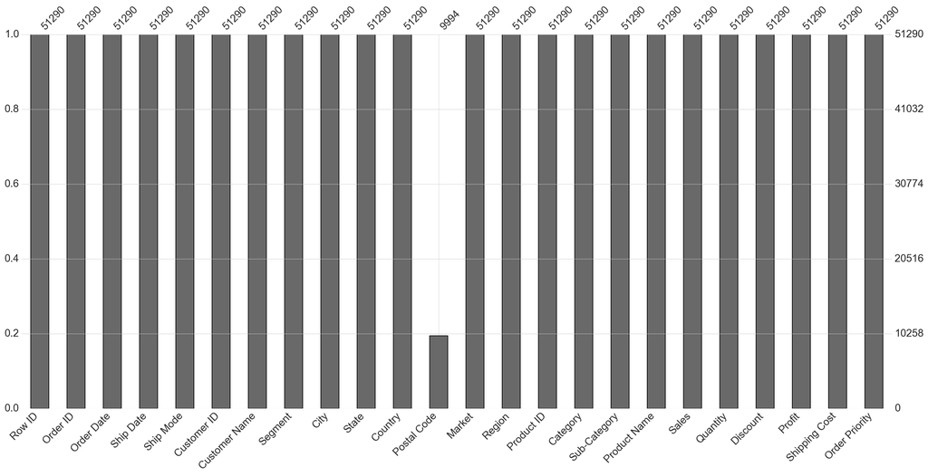

```python
import missingno as miss
miss.bar(ogdata)
plt.show()
```

可以看出除了地区邮编之外数据很完整，而邮编的确实并不影响进行分析

## 对数据根据Order Date排序得到源数据ogdata表

```python
data1=ogdata.loc[0:20066,:]
data2=ogdata.loc[20067:51289,:]
data1['Order Date']=pd.to_datetime(data1['Order Date'],format='%d/%m/%Y')
data2['Order Date']=pd.to_datetime(data2['Order Date'],format='%d-%m-%Y')
ogdata['Order Date']=data1['Order Date'].append(data2['Order Date'])
```

对排序好的数据筛选出['Order Date','Sales','Profit','year','month'] 构成业务表sales_data

# 观察数据分布

```python
#ogdata_new是按照时间升序的新数据
ogdata_new=ogdata.sort_values(by='Order Date',ascending=True,na_position='first')
ogdata_new['year']=ogdata_new['Order Date'].map(lambda x:x.year)
ogdata_new['month']=ogdata_new['Order Date'].map(lambda x:x.month)
sales_data=ogdata_new[['Order Date','Sales','Profit','year','month']]#构造业务表
sales_data.describe()
```

|  | Sales | Profit | year | month |
| --- | --- | --- | --- | --- |
| count | 51290.000000 | 51290.000000 | 51290.000000 | 51290.000000 |
| mean | 246.490581 | 28.610982 | 2012.777208 | 7.522636 |
| std | 487.565361 | 174.340972 | 1.098931 | 3.300056 |
| min | 0.444000 | -6599.978000 | 2011.000000 | 1.000000 |
| 25% | 30.758625 | 0.000000 | 2012.000000 | 5.000000 |
| 50% | 85.053000 | 9.240000 | 2013.000000 | 8.000000 |
| 75% | 251.053200 | 36.810000 | 2014.000000 | 10.000000 |
| max | 22638.480000 | 8399.976000 | 2014.000000 | 12.000000 |

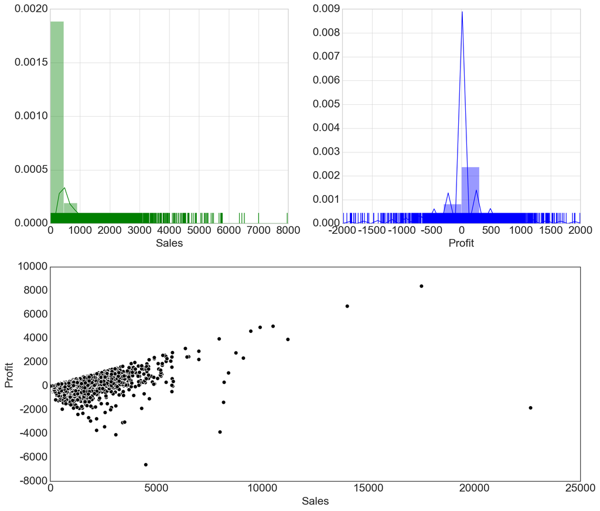

```python
plt.rcParams['font.size'] =18
sns.set_style('whitegrid')
fig=plt.figure(figsize=(14,12))
ax1=plt.subplot(221)
ax2=plt.subplot(222)
sns.distplot(sales_data['Sales'],ax=ax1,color='g',rug=True)
ax1.set_xlim(0,8000)
sns.distplot(sales_data['Profit'],ax=ax2,rug=True)
ax2.set_xlim(-2000,2000)
with sns.axes_style("white"):
    plt.subplot(212)
    sns.scatterplot(data=sales_data,x='Sales',y='Profit',s=42,color='black')
    plt.xlim(left=0)
plt.tight_layout()
plt.savefig('数据分布.png',dpi=300)
plt.show()
```

# 整体运营情况分析

## 销售额

### 年销售额和增长率

```python
gb=sales_data.groupby(['year','month'])
sale_year=gb.sum()
sale_year
year_2011=sale_year.loc[(2011,slice(None)),:].reset_index()
year_2012=sale_year.loc[(2012,slice(None)),:].reset_index()
year_2013=sale_year.loc[(2013,slice(None)),:].reset_index()
year_2014=sale_year.loc[(2014,slice(None)),:].reset_index()
sales=pd.concat([year_2011['Sales'],year_2012['Sales'],
                 year_2013['Sales'],year_2014['Sales']],axis=1)
sales.columns=['Sales-2011','Sales-2012','Sales-2013','Sales-2014']
sales.index=['Jau','Feb','Mar','Apr','May','Jun','Jul','Aug','Sep','Oct','Nov','Dec']
```

```python
#取消科学计数法
pd.set_option('float_format', lambda x: '%.6f' % x)
```

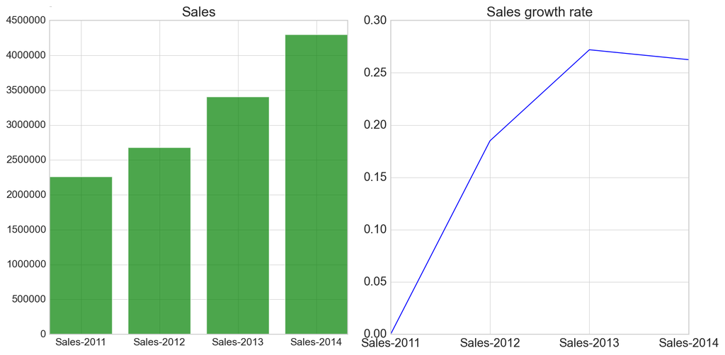

```python
plt.rcParams['font.size'] =14
plt.rcParams['font.sans-serif']=['SimHei']
plt.style.use('seaborn-whitegrid')
sale_rate=[0]
for i in range(3):
    sale_rate.append((sales.sum()[i+1]-sales.sum()[i])/sales.sum()[i])
sales_sum_and_rate=pd.DataFrame({'sales_sum':sales.sum(),'sale_rate':sale_rate})
del i
gc.collect()
fig,ax=plt.subplots(1,2,figsize=(12,6))
ax[0].bar(sales_sum_and_rate.index.tolist(),sales_sum_and_rate['sales_sum'],color= 'g',alpha=0.7)
ax[0].tick_params(labelsize=12)
ax[0].set_title('Sales',size=16)
ax[0].text(-0.4,4700000,'/万美元',fontsize=1)
ax[1].plot(sales_sum_and_rate.index.tolist(),sales_sum_and_rate['sale_rate'])
ax[1].set_title('Sales growth rate',size=16)
plt.tight_layout()
fig.savefig('年营业额.png',dpi=300)
plt.show()
```

#### 结论

通过可视化可以看出，结合年销售额和年增长率来看整体处于稳定上涨趋势，销售额也达到了430W左右，是一家规模比较大的超市

### 销售额同比

```python
sales.style.background_gradient(cmap='Blues',axis =0)
```

|  | Sales-2011 | Sales-2012 | Sales-2013 | Sales-2014 |
| --- | --- | --- | --- | --- |
| Jau | 98898.488860 | 135780.720240 | 199185.907380 | 241268.555660 |
| Feb | 91152.156980 | 100510.216980 | 167239.650400 | 184837.355560 |
| Mar | 145729.367360 | 163076.771160 | 198594.030120 | 263100.772620 |
| Apr | 116915.764180 | 161052.269520 | 177821.316840 | 242771.861300 |
| May | 146747.836100 | 208364.891240 | 260498.564700 | 288401.046140 |
| Jun | 215207.380220 | 256175.698420 | 396519.611900 | 401814.063100 |
| Jul | 115510.419120 | 145236.785120 | 229928.952000 | 258705.680480 |
| Aug | 207581.491220 | 303142.942380 | 326488.789360 | 456619.942360 |
| Sep | 290214.455340 | 289389.165640 | 376619.245680 | 481157.243700 |
| Oct | 199071.264040 | 252939.850200 | 293406.642880 | 422766.629160 |
| Nov | 298496.537520 | 323512.416900 | 373989.360100 | 555279.027000 |
| Dec | 333925.734600 | 338256.966600 | 405454.378020 | 503143.693480 |

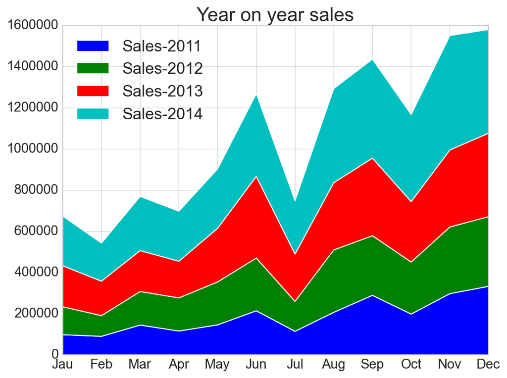

```python
plt.style.use('seaborn-whitegrid')
plt.stackplot(sales.index.tolist(),sales['Sales-2011'],sales['Sales-2012'],sales['Sales-2013'],
              sales['Sales-2014'],labels=sales.columns.tolist(),cmap='cool')
plt.legend(loc='upper left')
plt.title('Year on year sales',size=20)
plt.savefig('月份对销售额的影响.png',dpi=300)
plt.show()
```

#### 结论

可以明显发现上半年的销售额低于下半年  
对于旺季的月份，运营推广等策略要继续维持，还可以加大投入，提高整体销售额,对于淡季的月份，可以结合产品特点进行新产品拓展，举办一些促销活动等吸引客户  
另外七月份的营销额普遍会下降

### 销售额同比增长率

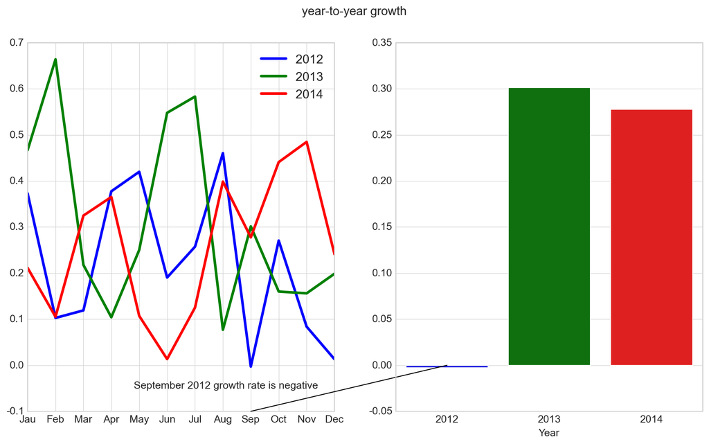

```python
from matplotlib.patches import ConnectionPatch# 链接两个字图
yeartoyear=pd.DataFrame()
yeartoyear['rise_2012']=(sales['Sales-2012']-sales['Sales-2011'])/sales['Sales-2011']
yeartoyear['rise_2013']=(sales['Sales-2013']-sales['Sales-2012'])/sales['Sales-2012']
yeartoyear['rise_2014']=(sales['Sales-2014']-sales['Sales-2013'])/sales['Sales-2013']
pd.set_option('float_format', lambda x: '%.6f' % x)#定义显示保留6位小数
fig,ax=plt.subplots(1,2,figsize=(14,7.4))
ax[0].plot(yeartoyear.index.tolist(),yeartoyear['rise_2012'],linewidth=3,label='2012')
ax[0].plot(yeartoyear.index.tolist(),yeartoyear['rise_2013'],linewidth=3,label='2013')
ax[0].plot(yeartoyear.index.tolist(),yeartoyear['rise_2014'],linewidth=3,label='2014')
ax[0].legend()
ax[0].text(3.8,-0.05,'September 2012 growth rate is negative')
#在两个子图中间画线
sns.barplot(['2012','2013','2014'],yeartoyear.loc['Sep'].values)
xy=(8,-0.1)
xy2 = (0,0)
con = ConnectionPatch(xyA=xy,xyB=xy2,coordsA='data',coordsB='data',axesA=ax[0],axesB=ax[1],color='black')
ax[1].add_artist(con)
ax[1].set_xlabel('Year')
fig.suptitle('year-to-year growth',size=14)
plt.savefig('销售额同比增长率.png',dpi=300)
plt.show()
```

#### 结论

2012年和2014的同比销售额增长率趋势相似，2013年比较反常二月和六月同比增长率升高，推测2013年应该采取了不同的销售策略，采取了侧重了冬季和夏季的销售策略。  
2012和2014都是采取全年平稳策略。但是在六月都有明显的下降。  
除此之外，2012年的九月还出现了同比增长率为负的情况

## 利润

### 年利润和增长率

```python
ga=sales_data.groupby(['year','month'])
ga=ga.sum()
year_2011=ga.loc[(2011,slice(None)),:].reset_index()
year_2012=ga.loc[(2012,slice(None)),:].reset_index()
year_2013=ga.loc[(2013,slice(None)),:].reset_index()
year_2014=ga.loc[(2014,slice(None)),:].reset_index()
Profit_data=pd.concat([year_2011['Profit'],year_2012['Profit'],year_2013['Profit'],year_2014['Profit']],axis=1)
Profit_data.index=['Jau','Feb','Mar','Apr','May','Jun','Jul','Aug','Sep','Oct','Nov','Dec']
Profit_data.columns=['profit_2011','profit_2012','profit_2013','profit_2014']
profit=pd.concat([sales_sum_and_rate.reset_index().drop(columns=['index','sale_rate']),
                  Profit_data.sum().reset_index()[0]],axis=1)
profit.index=['2011','2012','2013','2014']
profit.columns=['sales_sum','profit_sum']
rise_rate=[0]
profit_rate=[profit.iloc[0]['profit_sum']/profit.iloc[0]['sales_sum']]
for i in range(3):
    rise_rate.append((profit.iloc[i+1]['profit_sum']-profit.iloc[i]['profit_sum'])/profit.iloc[i]['profit_sum'])
    profit_rate.append(profit.iloc[i+1]['profit_sum']/profit.iloc[i+1]['sales_sum'])
del i
gc.collect()
profit['rise_rate']=rise_rate
profit['profit_rate']=profit_rate
```

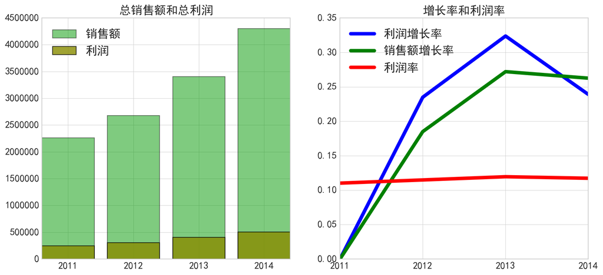

```python
plt.rcParams['font.sans-serif']=['SimHei']
plt.figure(figsize=(14,6))
ax1=plt.subplot(121)
plt.bar(profit.index.tolist(),profit['sales_sum'],alpha=0.5,color='#009900',label='销售额')
plt.bar(profit.index.tolist(),profit['profit_sum'],alpha=0.8,color='#888C00',label='利润')
plt.legend(loc='upper left')
ax1.set_title('总销售额和总利润')
ax2=plt.subplot(122)
plt.plot(profit.index.tolist(),profit['rise_rate'],label='利润增长率',linewidth='5')
plt.plot(profit.index.tolist(),sales_sum_and_rate['sale_rate'],label='销售额增长率',linewidth='5')
plt.plot(profit.index.tolist(),profit['profit_rate'],label='利润率',linewidth='5')
plt.legend(loc='upper left')
ax2.set_title('增长率和利润率')
plt.savefig('利润和销售额.png',dpi=300)
plt.show()
```

#### 结论

通过图表可以看出，每年的利润和销售额一样，是在逐年增加的，说明经营比较妥善，而且与销售额增长率对比来看，除了14年利润率同比下降及对比销售额增长率（26.25%）低之外，前两年均高出销售额增长率，可能14年促销让利比较多  
利润率总体平稳，稳定在11%-12%之间。

### 利润同比,利润率同比,利润同比增长率

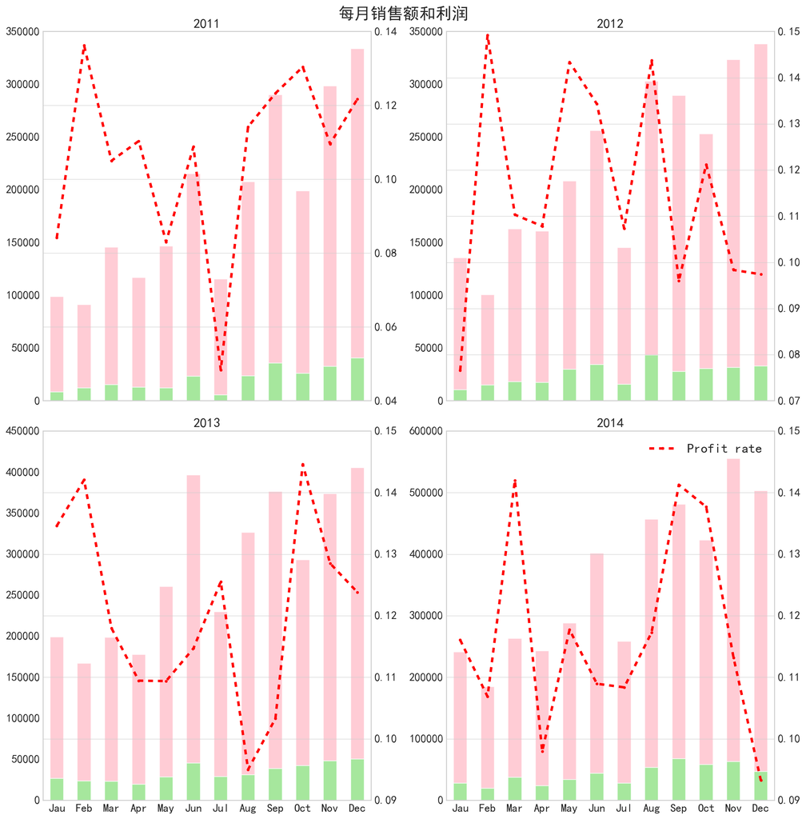

```python
plt.rcParams['font.sans-serif']=['SimHei']
profit_rate_month=pd.DataFrame()
profit_rate_month['2011']=Profit_data['profit_2011']/sales['Sales-2011']
profit_rate_month['2012']=Profit_data['profit_2012']/sales['Sales-2012']
profit_rate_month['2013']=Profit_data['profit_2013']/sales['Sales-2013']
profit_rate_month['2014']=Profit_data['profit_2014']/sales['Sales-2014']
fig,ax=plt.subplots(2,2,figsize=(14,14))
k=0
for x in range(2):
    for y in range(2):
        ax[x][y].set_title('{}'.format(2011+k))
        a=sales.iloc[:,k].plot(kind='bar',color='pink',ax=ax[x][y],label='Sales',alpha=0.8)
        b=Profit_data.iloc[:,k].plot(kind='bar',color='lightgreen',ax=ax[x][y],label='Profit',alpha=0.8)
        profit_rate_month.iloc[:,k].plot(secondary_y=True,style='--r.',ax=ax[x][y],label='Profit rate',
                                         linewidth=3)
        k+=1
del x,y
gc.collect()
plt.legend(loc='upper right')
plt.suptitle('每月销售额和利润',size=20,y=1.0001)
plt.tight_layout()
plt.savefig('每月销售额和利润.png',dpi=300)
plt.show()
```

#### 结论

利润率和利润率基本成正比，且利润率基本都维持在4%-15%左右

## 客单价

```python
price=ogdata_new[['year','Order Date','Customer ID','Sales']]
price_2011=price[price['year']==2011].reset_index(drop=True)
price_2012=price[price['year']==2012].reset_index(drop=True)
price_2013=price[price['year']==2013].reset_index(drop=True)
price_2014=price[price['year']==2014].reset_index(drop=True)
times=[]#消费次数，一个Order Date和Customer ID确定一次消费
times.append(price_2011.drop_duplicates(subset=['Order Date', 'Customer ID']).shape[0])
times.append(price_2012.drop_duplicates(subset=['Order Date', 'Customer ID']).shape[0])
times.append(price_2013.drop_duplicates(subset=['Order Date', 'Customer ID']).shape[0])
times.append(price_2014.drop_duplicates(subset=['Order Date', 'Customer ID']).shape[0])
unit_price_list=[]#客单价=先手额/消费次数
unit_price_list.append(price_2011['Sales'].sum()/times[0])
unit_price_list.append(price_2012['Sales'].sum()/times[1])
unit_price_list.append(price_2013['Sales'].sum()/times[2])
unit_price_list.append(price_2014['Sales'].sum()/times[3])
unit_price=pd.DataFrame({'Number of purchases':times,'unit_price':unit_price_list})
unit_price.index=[2011,2012,2013,2014]
unit_price
```

|  | Number of purchases | unit_price |
| --- | --- | --- |
| 2011 | 4453 | 507.399707 |
| 2012 | 5392 | 496.557621 |
| 2013 | 6753 | 504.330882 |
| 2014 | 8696 | 494.464797 |

#### 结论

每年的客单价变化不大，比较稳定。交易成交量逐年提升。

## 销量

```python
quantity=ogdata_new.loc[:,['year','month','Quantity','Region','Category','Sub-Category']]
quantity_time=quantity.groupby(['year','month'])['Quantity'].sum()
year_2011=quantity_time.loc[2011,:].reset_index()
year_2012=quantity_time.loc[2012,:].reset_index()
year_2013=quantity_time.loc[2013,:].reset_index()
year_2014=quantity_time.loc[2014,:].reset_index()
quantity_year=pd.concat([year_2011['Quantity'],year_2012['Quantity'],
                         year_2013['Quantity'],year_2014['Quantity']],axis=1)
quantity_year.index=['Jau','Feb','Mar','Apr','May','Jun','Jul','Aug','Sep','Oct','Nov','Dec']
quantity_year.columns=['quantity2011','quantity2012','quantity2013','quantity2014']
del quantity_time
gc.collect()
quantity_year.style.background_gradient(cmap='pink_r')
```

|  | quantity2011 | quantity2012 | quantity2013 | quantity2014 |
| --- | --- | --- | --- | --- |
| Jau | 1463 | 1845 | 2413 | 3122 |
| Feb | 1224 | 1473 | 2102 | 2482 |
| Mar | 1836 | 2237 | 2686 | 3722 |
| Apr | 2020 | 2250 | 2688 | 3594 |
| May | 2013 | 2921 | 3808 | 4300 |
| Jun | 3112 | 3671 | 5327 | 6009 |
| Jul | 1774 | 2321 | 3252 | 3637 |
| Aug | 3035 | 3818 | 4934 | 5824 |
| Sep | 3707 | 4205 | 5793 | 6837 |
| Oct | 2727 | 3563 | 3883 | 5876 |
| Nov | 4039 | 5193 | 5556 | 7706 |
| Dec | 4493 | 4614 | 5694 | 7513 |

#### 结论

销量逐年稳定增长，且下半年的销量普遍高于上半年

## 市场布局

### 不同地区分店销售额对比

```python
loco=ogdata_new.loc[:,['year','Sales','Market']].groupby('Market').sum()
loco.drop('year',axis=1).style.bar(color='red',vmax=loco['Sales'].sum())
```

| Market | Sales |
| --- | --- |
| APAC | 3585744.129000 |
| Africa | 783773.211000 |
| Canada | 66928.170000 |
| EMEA | 806161.311000 |
| EU | 2938089.061500 |
| LATAM | 2164605.167080 |
| US | 2297200.860300 |

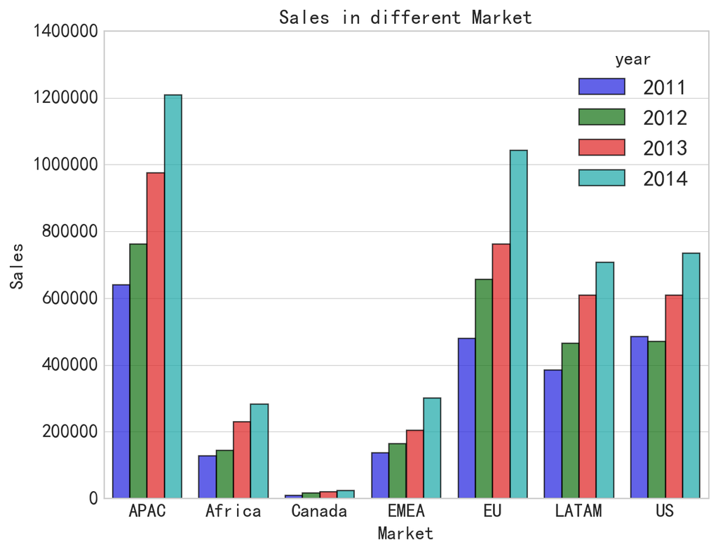

```python
loco_date=ogdata_new.loc[:,['year','Sales','Market']].groupby(['Market','year']).sum()
loco_date=loco_date.reset_index()
sns.barplot(data=loco_date,x='Market',hue='year',y='Sales',alpha=0.7)
plt.title('Sales in different Market',size=15)
plt.savefig('不同地区销售额对比.png',dpi=300)
plt.show()
```

## 促销折扣影响

```python
discount_data=ogdata_new.loc[:,['Profit','Sales','Discount','year','month']]
discount_data['Discount']=discount_data['Discount'].map(lambda x:'no discount' if x-0<0.0000001 else 'discount')
discount_year=discount_data.groupby(['year','Discount']).sum().drop('month',axis=1).reset_index()
discount_month=discount_data.groupby(['year','month','Discount']).sum()
```

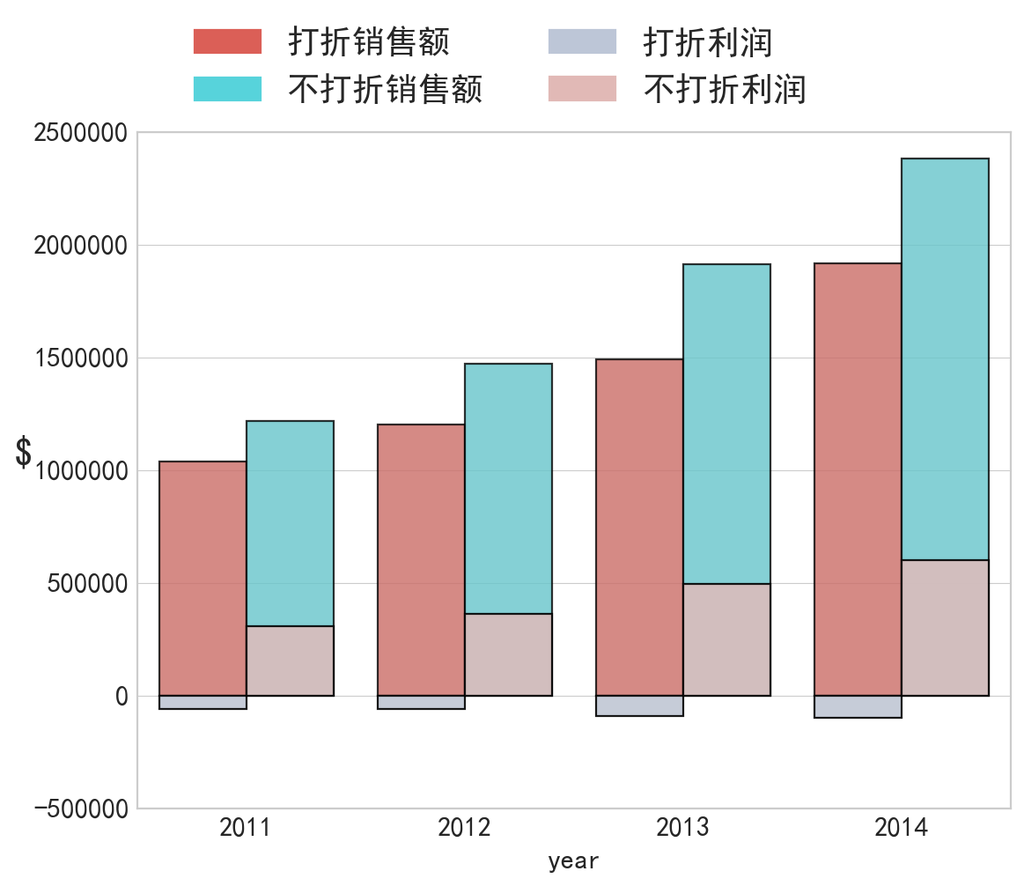

```python
import matplotlib.patches as mpatches#自定义图例
plt.rcParams['axes.unicode_minus'] = False
sns.barplot(data=discount_year,x='year',y='Sales',hue='Discount',palette=sns.color_palette('hls',2),alpha=0.8)
sns.barplot(data=discount_year,x='year',y='Profit',hue='Discount',palette=sns.color_palette('vlag',2),alpha=0.9)
labels = ['打折销售额', '不打折销售额', '打折利润', '不打折利润']
color = sns.color_palette('hls',2)
color.extend(sns.color_palette('vlag',2))
patches = [ mpatches.Patch(color=color[i], label="{}".format(labels[i]) ) for i in range(len(color)) ]
plt.legend(handles=patches,bbox_to_anchor=(0.8,1.2), ncol=2)
plt.ylabel('$',size=20,rotation=0)
plt.savefig('折扣对利润和销售额影响.png',dpi=300)
plt.show()
```

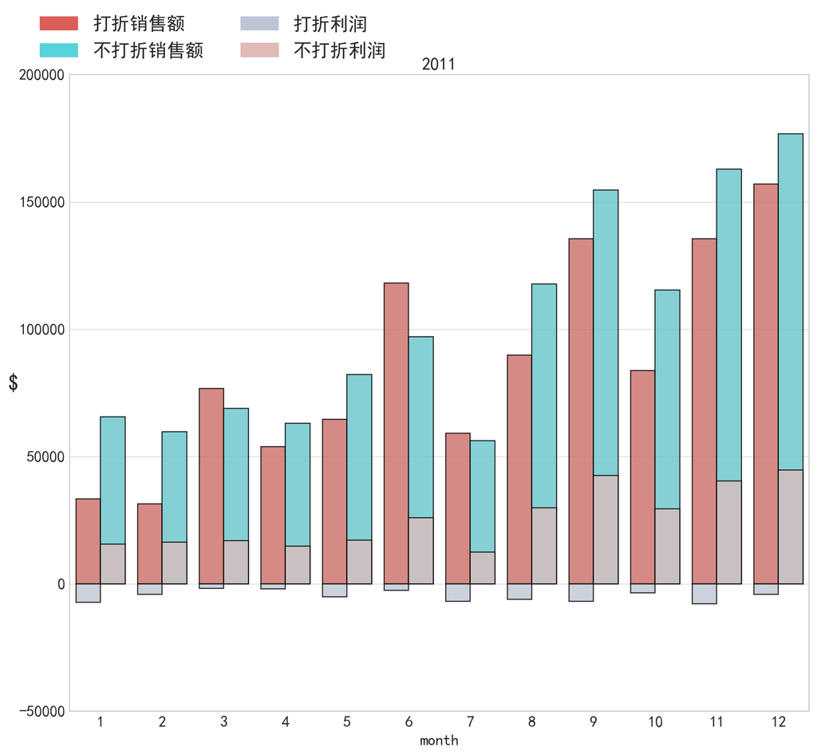

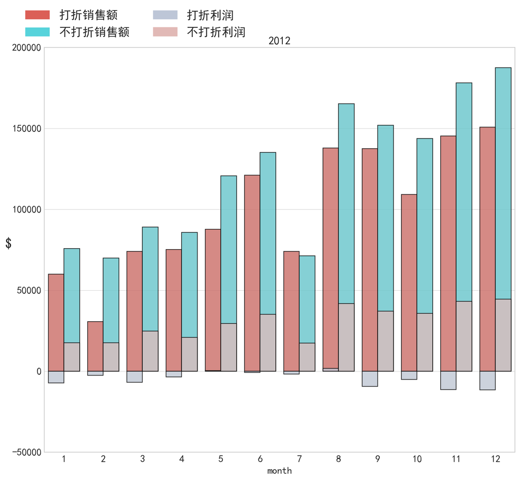

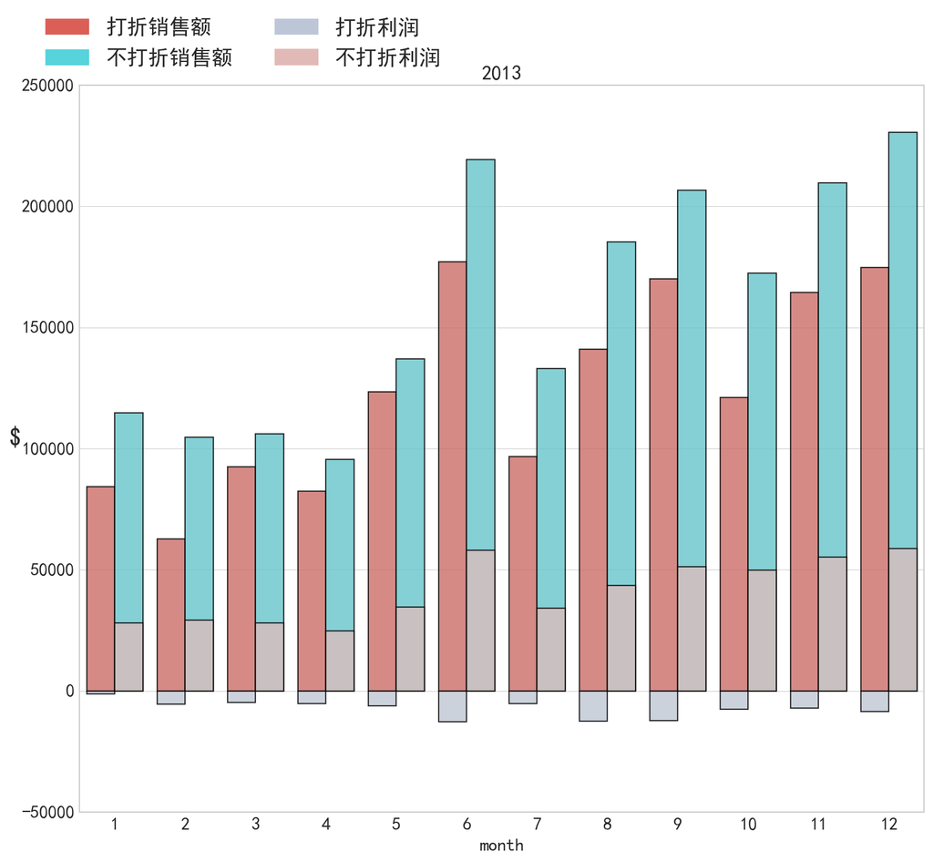

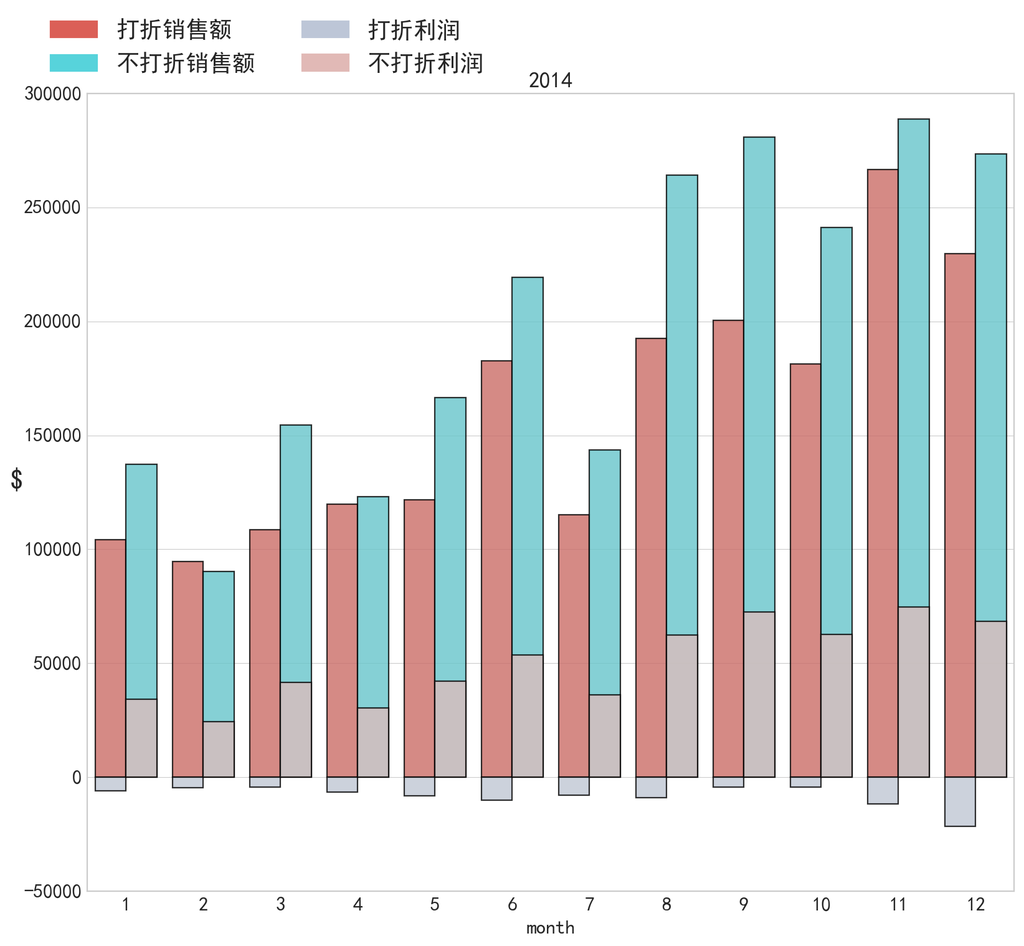

```
已保存2011-2014年打折对销售和利润影响情况
```

```python
year_list=[]
year_list.append(discount_month.loc[2011,:].reset_index())
year_list.append(discount_month.loc[2012,:].reset_index())
year_list.append(discount_month.loc[2013,:].reset_index())
year_list.append(discount_month.loc[2014,:].reset_index())
time=2011
for i in year_list:
    fig=plt.figure(figsize=(12,10))
    sns.barplot(data=i,x='month',y='Sales',hue='Discount',palette=sns.color_palette('hls',2),alpha=0.8)
    sns.barplot(data=i,x='month',y='Profit',hue='Discount',palette=sns.color_palette('vlag',2),alpha=0.8)
    labels = ['打折销售额', '不打折销售额', '打折利润', '不打折利润']
    color = sns.color_palette('hls',2)
    color.extend(sns.color_palette('vlag',2))
    patches = [ mpatches.Patch(color=color[i], label="{}".format(labels[i]) ) for i in range(len(color)) ]
    plt.legend(handles=patches,bbox_to_anchor=(0.45,1.12), ncol=2)
    plt.ylabel('$',size=20,rotation=0)
    plt.title('{}'.format(time),size=16)
    fig.savefig('{}年打折对销售和利润影响情况.png'.format(time),dpi=300)
    plt.show()
    #plt.clf()
    time+=1
print('已保存2011-2014年打折对销售和利润影响情况')
```

### 结论

可以看出前面有些时间比如2013年的6月,的销售额同比增长率大幅提高的原因是由于加大了打折促销的力度  
同时也看出2014年利润增长率下降的原因是由于打折促销力度变大，并且在12月份年底可能是冲业绩，打折力度非常大。

# 商品结构

```python
goods_data=ogdata_new.loc[:,['Sales','Profit','Category','Sub-Category']]
Furniture=goods_data.groupby(['Category','Sub-Category']).sum().loc['Furniture',:]
Technology=goods_data.groupby(['Category','Sub-Category']).sum().loc['Technology',:]
Office_Supplies=goods_data.groupby(['Category','Sub-Category']).sum().loc['Office Supplies',:]
```

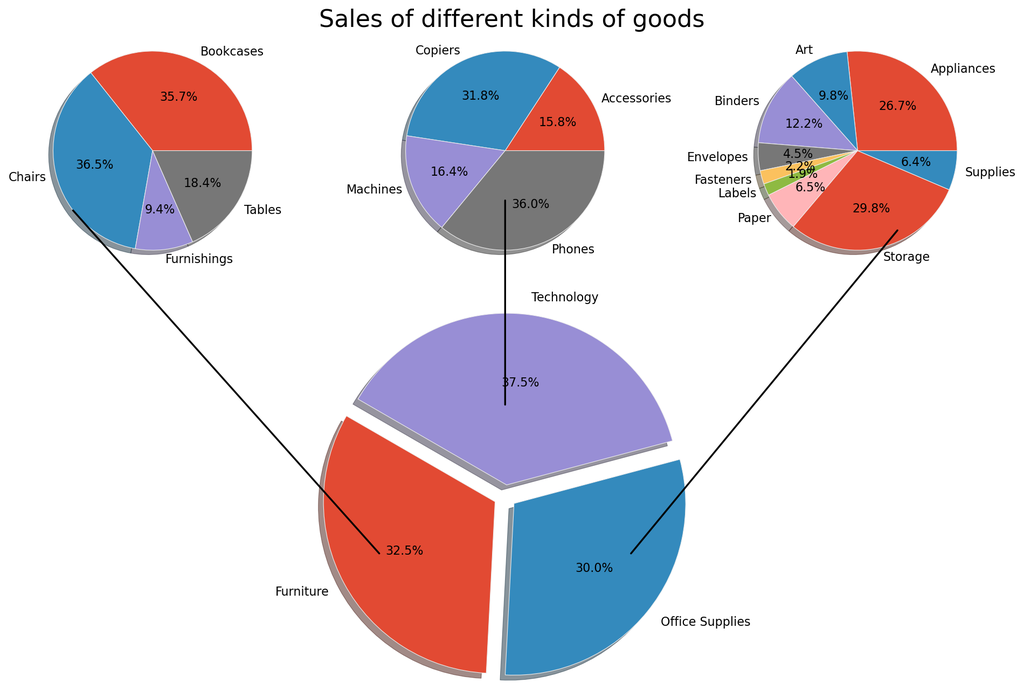

```python
plt.style.use('ggplot')
from matplotlib.patches import ConnectionPatch
x=goods_data.groupby('Category').sum().reset_index()['Sales'].values.tolist()
labels=goods_data.groupby('Category').sum().index.tolist()
explode=[0.1,0.1,0.1]
fig=plt.figure(figsize=(12,8))
ax1=plt.subplot(231)
plt.pie(x=Furniture['Sales'].values.tolist(),labels=Furniture.index.tolist(),shadow=True,autopct='%1.1f%%')
ax2=plt.subplot(232)
plt.pie(x=Technology['Sales'].values.tolist(),labels=Technology.index.tolist(),shadow=True,autopct='%1.1f%%')
ax3=plt.subplot(233)
plt.pie(x=Office_Supplies['Sales'].values.tolist(),labels=Office_Supplies.index.tolist(),shadow=True,autopct='%1.1f%%')
ax4=plt.subplot(212)
plt.pie(x=x,explode=explode,labels=labels,shadow=True,radius=1.5,autopct='%1.1f%%',startangle=150)
plt.suptitle('Sales')
plt.tight_layout()
xy1=(-1.1,-0.5)
xy2 = (-0.8,-0.6)
xy3=(0,0.8)
xy4=(0,-0.5)
xy5=(1.1,-0.5)
xy6=(0.4,-0.8)
con1 = ConnectionPatch(xyA=xy1,xyB=xy2,coordsA='data',coordsB='data',axesA=ax4,axesB=ax1,color='black',linewidth=1.5)
con2 = ConnectionPatch(xyA=xy3,xyB=xy4,coordsA='data',coordsB='data',axesA=ax4,axesB=ax2,color='black',linewidth=1.5)
con3 = ConnectionPatch(xyA=xy5,xyB=xy6,coordsA='data',coordsB='data',axesA=ax4,axesB=ax3,color='black',linewidth=1.5)
ax4.add_artist(con1)
ax4.add_artist(con2)
ax4.add_artist(con3)
plt.suptitle('Sales of different kinds of goods',size=20)
plt.savefig('不同商品销售额.png',dpi=300)
plt.show()
```

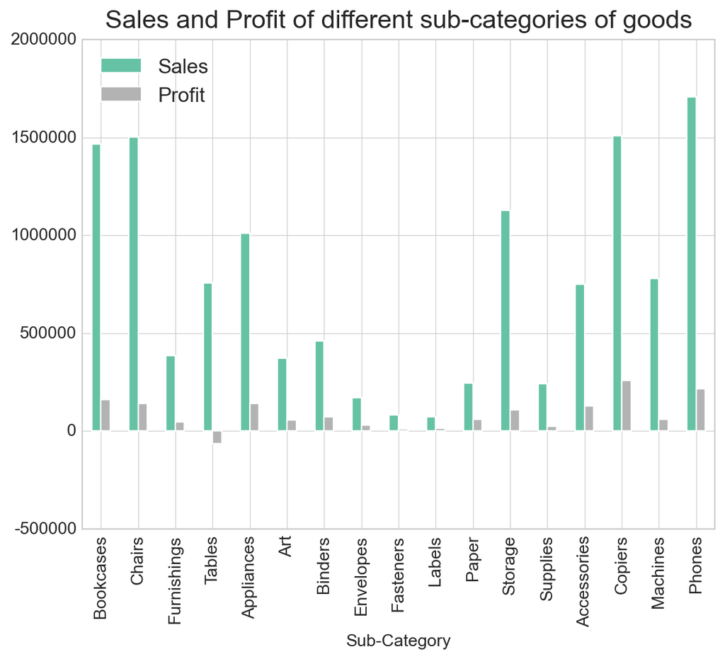

```python
plt.rcParams['axes.unicode_minus'] = False
#plt.figure(figsize=(12,8))
sub_goods=pd.concat([Furniture,Office_Supplies,Technology])
sub_goods.plot(kind='bar',cmap='Set2')
plt.title('Sales and Profit of different sub-categories of goods',size=18,y=1.01)
plt.savefig('不同子类别销售情况.png',dpi=300)
plt.show()
```

## 结论

Furniture(家具),Technology(电子产品),Office_Supplies(办公用具)三大类销售额比重比较平均。并且出furniture中Bookcases(书柜)、Chairs(椅子)、Tables(桌子)，Office supplies中Appliances(电器)、Storage(储藏箱)，Technology中Accessories(附件)、Copiers(复印机)、Machines(机器)、Phones(电话/手机)，是整体商品中销售比较好的。

从著名的帕累托二八法则分析也可以看出，这几款商品的总销售占比达到80%以上，应该是自家优势主营商品，后续经营中应继续保持，可以结合销售策略加大投入，形成直营品牌。而对于销量末尾的商品可以根据捆绑销售等策略，依靠热门商品的连带效应销售  
另外Tables(桌子)的利润是负，表明这个产品目前处于让利促销的亏损状态，通过检查原数据，发现Tabels大部分都在打折，打折的销量最高达76%。需要结合实际业务进行分析，适当改善经营策略，如果是在清库存，这个效果还是不错的，但如果不是，说明这个商品存在销售瓶颈，需要考虑采取其他销售策略

# 客户结构

```python
Segment=ogdata_new.loc[:,['Sales','Profit','year','Segment']]
```

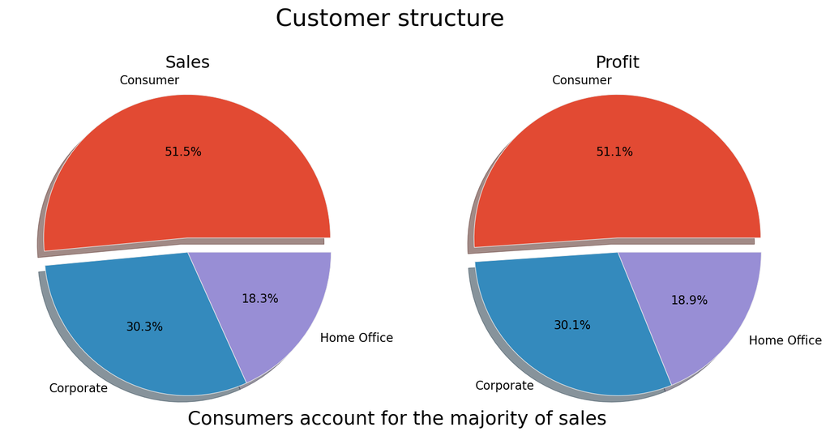

```python
fig=plt.figure(figsize=(12,6))
ex=[0.1,0,0]
ax1=plt.subplot(121)
plt.pie(x=Segment.groupby('Segment').sum()['Sales'].values.tolist(),explode=ex,radius=1,
        labels=Segment.groupby('Segment').sum()['Sales'].index.tolist(),
       shadow=True,autopct='%1.1f%%')
plt.text(x=0,y=-1.2,s='Consumers account for the majority of sales',size=16)
plt.title('Sales')
ax1=plt.subplot(122)
plt.pie(x=Segment.groupby('Segment').sum()['Profit'].values.tolist(),explode=ex,radius=1,
        labels=Segment.groupby('Segment').sum()['Profit'].index.tolist(),
       shadow=True,autopct='%1.1f%%')
plt.title('Profit')
plt.suptitle('Customer structure',size=20)
plt.savefig('客户结构.png',dpi=300)
plt.show()
```

```python
ga=Segment.groupby(['Segment','year']).sum()
Consumer=ga.loc['Consumer',:]
Corporate=ga.loc['Corporate',:]
Home_Office=ga.loc['Home Office',:]
```

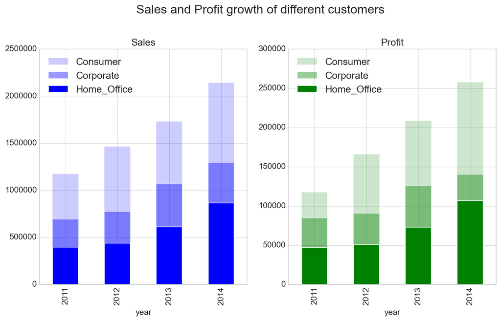

```python
plt.figure(figsize=(12,6))
ax1=plt.subplot(121)
Consumer['Sales'].plot(kind='bar',alpha=0.2)
Corporate['Sales'].plot(kind='bar',alpha=0.4)
Home_Office['Sales'].plot(kind='bar')
plt.legend(['Consumer','Corporate','Home_Office'],loc='upper left')
plt.title('Sales')
ax1=plt.subplot(122)
Consumer['Profit'].plot(kind='bar',alpha=0.2,color='green')
Corporate['Profit'].plot(kind='bar',alpha=0.4,color='green')
Home_Office['Profit'].plot(kind='bar',color='green')
plt.legend(['Consumer','Corporate','Home_Office'],loc='upper left')
plt.title('Profit')
plt.suptitle('Sales and Profit growth of different customers',size=18,y=1.05)
plt.show()
```

从以上两个图表看出，超过一半以上的客户为普通消费者consumer，且每类客户每年贡献的销售额均在保持增长趋势，客户结构比较稳定的。其中corporate和home office维系的好一般属于稳定长期客户，还可以有增长空间

# 总体结论

从销售额，利润，客单价，销量，市场布局，商品结构和客户结构几个方面综合来看，是一家运营情况健康，有持续扩展趋势的超市。  
当然也可以进一步的进行分析，如不同地区的商品流行度，新老客户的比例等等指标，构建RFM模型分析对客户分类等等方式对超市日后的销售战略进一步完善